# Bodyfat Prediction by Bagging

```python
## Import the libraries

import pandas as pd
from numpy import mean
from numpy import std
import matplotlib.pyplot as plt
import seaborn as sns
from sklearn.model_selection import cross_val_score
from sklearn.model_selection import RepeatedKFold
from sklearn.ensemble import BaggingRegressor
import warnings
warnings.filterwarnings("ignore")
from sklearn.preprocessing import StandardScaler
from sklearn.model_selection import train_test_split
from sklearn.linear_model import LinearRegression, Ridge, Lasso
from sklearn.metrics import r2_score
from sklearn.metrics import mean_squared_error
from mlxtend.feature_selection import SequentialFeatureSelector
```

```python
## Getting the dataset
fat=pd.read_csv("/Github/bodyfat.csv")
```

## Exploratory Data Analysis

```python
fat.shape
```

```
(252, 15)
```

```python
fat.head()
```

|  | Density | BodyFat | Age | Weight | Height | Neck | Chest | Abdomen | Hip | Thigh | Knee | Ankle | Biceps | Forearm | Wrist |
| --- | --- | --- | --- | --- | --- | --- | --- | --- | --- | --- | --- | --- | --- | --- | --- |
| 0 | 1.0708 | 12.3 | 23 | 154.25 | 67.75 | 36.2 | 93.1 | 85.2 | 94.5 | 59.0 | 37.3 | 21.9 | 32.0 | 27.4 | 17.1 |
| 1 | 1.0853 | 6.1 | 22 | 173.25 | 72.25 | 38.5 | 93.6 | 83.0 | 98.7 | 58.7 | 37.3 | 23.4 | 30.5 | 28.9 | 18.2 |
| 2 | 1.0414 | 25.3 | 22 | 154.00 | 66.25 | 34.0 | 95.8 | 87.9 | 99.2 | 59.6 | 38.9 | 24.0 | 28.8 | 25.2 | 16.6 |
| 3 | 1.0751 | 10.4 | 26 | 184.75 | 72.25 | 37.4 | 101.8 | 86.4 | 101.2 | 60.1 | 37.3 | 22.8 | 32.4 | 29.4 | 18.2 |
| 4 | 1.0340 | 28.7 | 24 | 184.25 | 71.25 | 34.4 | 97.3 | 100.0 | 101.9 | 63.2 | 42.2 | 24.0 | 32.2 | 27.7 | 17.7 |

```python
fat.info()
```

```
<class 'pandas.core.frame.DataFrame'>
RangeIndex: 252 entries, 0 to 251
Data columns (total 15 columns):
 #   Column   Non-Null Count  Dtype
---  ------   --------------  -----
 0   Density  252 non-null    float64
 1   BodyFat  252 non-null    float64
 2   Age      252 non-null    int64
 3   Weight   252 non-null    float64
 4   Height   252 non-null    float64
 5   Neck     252 non-null    float64
 6   Chest    252 non-null    float64
 7   Abdomen  252 non-null    float64
 8   Hip      252 non-null    float64
 9   Thigh    252 non-null    float64
 10  Knee     252 non-null    float64
 11  Ankle    252 non-null    float64
 12  Biceps   252 non-null    float64
 13  Forearm  252 non-null    float64
 14  Wrist    252 non-null    float64
dtypes: float64(14), int64(1)
memory usage: 29.7 KB
```

Bodyfat: Percentage of bodyfat using Brozek's equation [2], 457/Density - 414.2, Age: Age of the men(yrs), Weight in lbs, Height in inches, Neck, Chest, Abdomen, Hip, Ankle, Thigh, Biceps(expanded), Forearm, Wrist (all circumferences) in cm and Density in gm/cubic cm. We can clearly see density in Brozek’s formula for percentage of bodyfat. So, we remove density variable from the dataset and keep the rest.

```python
fat=fat.drop('Density',axis=1)
```

```python
fat.head()
```

|  | BodyFat | Age | Weight | Height | Neck | Chest | Abdomen | Hip | Thigh | Knee | Ankle | Biceps | Forearm | Wrist |
| --- | --- | --- | --- | --- | --- | --- | --- | --- | --- | --- | --- | --- | --- | --- |
| 0 | 12.3 | 23 | 154.25 | 67.75 | 36.2 | 93.1 | 85.2 | 94.5 | 59.0 | 37.3 | 21.9 | 32.0 | 27.4 | 17.1 |
| 1 | 6.1 | 22 | 173.25 | 72.25 | 38.5 | 93.6 | 83.0 | 98.7 | 58.7 | 37.3 | 23.4 | 30.5 | 28.9 | 18.2 |
| 2 | 25.3 | 22 | 154.00 | 66.25 | 34.0 | 95.8 | 87.9 | 99.2 | 59.6 | 38.9 | 24.0 | 28.8 | 25.2 | 16.6 |
| 3 | 10.4 | 26 | 184.75 | 72.25 | 37.4 | 101.8 | 86.4 | 101.2 | 60.1 | 37.3 | 22.8 | 32.4 | 29.4 | 18.2 |
| 4 | 28.7 | 24 | 184.25 | 71.25 | 34.4 | 97.3 | 100.0 | 101.9 | 63.2 | 42.2 | 24.0 | 32.2 | 27.7 | 17.7 |

```python
## Checking missing values
fat.isna().sum() ## No missing values
```

```
BodyFat    0
Age        0
Weight     0
Height     0
Neck       0
Chest      0
Abdomen    0
Hip        0
Thigh      0
Knee       0
Ankle      0
Biceps     0
Forearm    0
Wrist      0
dtype: int64
```

```python
fat.describe()
```

|  | BodyFat | Age | Weight | Height | Neck | Chest | Abdomen | Hip | Thigh | Knee | Ankle | Biceps | Forearm | Wrist |
| --- | --- | --- | --- | --- | --- | --- | --- | --- | --- | --- | --- | --- | --- | --- |
| count | 252.000000 | 252.000000 | 252.000000 | 252.000000 | 252.000000 | 252.000000 | 252.000000 | 252.000000 | 252.000000 | 252.000000 | 252.000000 | 252.000000 | 252.000000 | 252.000000 |
| mean | 19.150794 | 44.884921 | 178.924405 | 70.148810 | 37.992063 | 100.824206 | 92.555952 | 99.904762 | 59.405952 | 38.590476 | 23.102381 | 32.273413 | 28.663889 | 18.229762 |
| std | 8.368740 | 12.602040 | 29.389160 | 3.662856 | 2.430913 | 8.430476 | 10.783077 | 7.164058 | 5.249952 | 2.411805 | 1.694893 | 3.021274 | 2.020691 | 0.933585 |
| min | 0.000000 | 22.000000 | 118.500000 | 29.500000 | 31.100000 | 79.300000 | 69.400000 | 85.000000 | 47.200000 | 33.000000 | 19.100000 | 24.800000 | 21.000000 | 15.800000 |
| 25% | 12.475000 | 35.750000 | 159.000000 | 68.250000 | 36.400000 | 94.350000 | 84.575000 | 95.500000 | 56.000000 | 36.975000 | 22.000000 | 30.200000 | 27.300000 | 17.600000 |
| 50% | 19.200000 | 43.000000 | 176.500000 | 70.000000 | 38.000000 | 99.650000 | 90.950000 | 99.300000 | 59.000000 | 38.500000 | 22.800000 | 32.050000 | 28.700000 | 18.300000 |
| 75% | 25.300000 | 54.000000 | 197.000000 | 72.250000 | 39.425000 | 105.375000 | 99.325000 | 103.525000 | 62.350000 | 39.925000 | 24.000000 | 34.325000 | 30.000000 | 18.800000 |
| max | 47.500000 | 81.000000 | 363.150000 | 77.750000 | 51.200000 | 136.200000 | 148.100000 | 147.700000 | 87.300000 | 49.100000 | 33.900000 | 45.000000 | 34.900000 | 21.400000 |

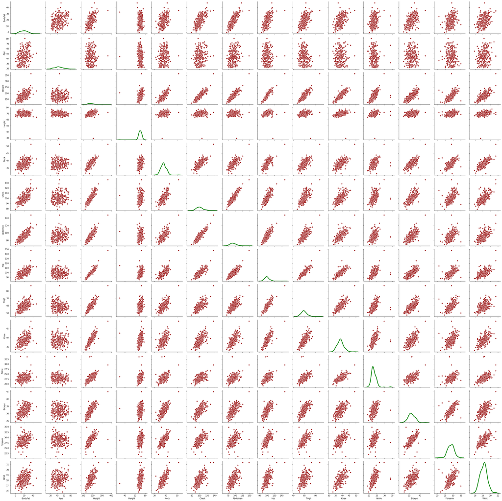

```python
## Scatter plot and the distribution of the variables
g = sns.PairGrid(fat)
g.map_offdiag(sns.scatterplot, color='brown')
g.map_diag(sns.kdeplot, lw=3, legend=False, color='green')
#g.fig.suptitle('Fig 1')
plt.show()
```

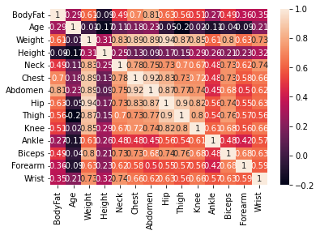

```python
## Correlation matrix between the numerical covariates

correlation_matrix = fat.corr().round(2)
sns.heatmap(data=correlation_matrix, annot=True)
```

From the summary statistics we do not see existence of many outliers. From the correlation matrix, we can see that bodyfat has strong positive correlations with abdomen whereas weight has quite strong correlation with neck, chest, abdomen, hip, thigh knee and biceps. Scatter plots are mostly following linear pattern. But we can identify a huge outlier with the plot between height and bodyfat. We can further confirm that using the histogram d Boxplot of height.

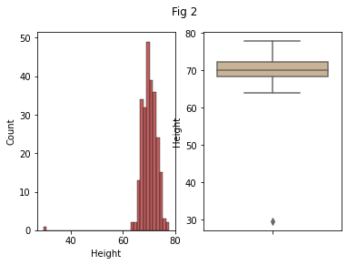

```python
## histogram and  of Height
fig, axes = plt.subplots(1, 2)
sns.histplot(ax=axes[0], data=fat, x="Height",color='brown')
sns.boxplot(ax=axes[1], data=fat, y="Height", color='tan')
fig.suptitle('Fig 2')
plt.show()
```

The histogram and boxplot of height (Fig 2) shows existence of data(height) less than 40 inches which does not look normal. So, we check all the data (Table 3) where height is less than 40 inches.

```python
fat[fat['Height']<40]
```

|  | BodyFat | Age | Weight | Height | Neck | Chest | Abdomen | Hip | Thigh | Knee | Ankle | Biceps | Forearm | Wrist |
| --- | --- | --- | --- | --- | --- | --- | --- | --- | --- | --- | --- | --- | --- | --- |
| 41 | 32.9 | 44 | 205.0 | 29.5 | 36.6 | 106.0 | 104.3 | 115.5 | 70.6 | 42.5 | 23.7 | 33.6 | 28.7 | 17.4 |

```python
fat['Height'][41]=69.5
```